# Programming for Data Science 2023

## Homework Assigment Three

Homework Assigment Three focus in the step-by-step implementation of a simple, yet popular, clustering algorithm, the **K-Means**. Although in most projects you will source algorithms from readily available implementations found in libraries such as scikit-learn or Keras, in some cases you will need to implement an algorithm yourself. For instance, if such algorithm is not available or if you want to implement a problem-specific modification. In that sense, learning to implement algorithms is an important part of your skillset.

Your submission will be graded according to the following guidelines:

1. **Execution** (does your program does what is asked from the exercise?
2. **Objectivity** (are you using the adequate libraries? are you using a library ... )
3. **Readibility** of your code (that includes comments, naming of variables, supporting text, etc ...)

Some questions might require that you make critical decisions, or design choices. In such cases, you will be graded according to your ability to justify and support your decisions.

**Comment your code properly, which includes naming your variables in a meaningful manner. Badly documented code will be penalized.**

This assignment is to be done in pairs, and remember that **you can't have the same pair as you had in Homeworks 1 and 2**.

**Students that are caught cheating will obtain a score of 0 points.**

The Homework 3 is worth 30% of your final grade.

The submission package should correspond to a .zip archive (.rar files are not accepted) with the following files:

1. Jupyter Notebook with the output of all the cells;
2. PDF/HTML print of your Jupyter Notebook (in jupyter go to File -> Download as -> HTML/PDF);
3. All text or .csv files exported as part of the exercises (if they exist). Do not upload the files downloaded/imported as part of the exercises.

**Please change the name of the notebook to "H3_\<student_1*id>*\<student_2_id>.ipynb", replacing \<student_id> by your student_id.**

Submission is done through the respective Moodle activity and only one of the group members has to submit the files.  
Deadline is the 26th of October at 23:59.  
A penality of 1 point per day late will be applied to late deliveries.

## **In this notebook you are allowed to use Pandas and Numpy.**

## Group Registration

Edit this cell with the information of the authors of this submission.

|  | Student Name | Student ID |
| --- | --- | --- |
| 1 | Nicolau Dulea | 20230544 |
| 2 | Rodrigo Silva | 20230536 |

## Clustering with K-Means

K-means is one of the simplest clustering algorithms, which you may already know from the course Data Mining. The K-means Algorithm consists in writing a program that proceeds as follows:

1. Choose value for K (number of clusters);
2. Initialize the locations of the centroids. This can be done by randomly selecting K points from the dataset as the initial locations of the centroids;
3. Compute the distance of all the other points to each of the K centroids;
4. Associate each point to the cluster of the closest centroid;
5. Update the centroid position. This can be done by computing the average coordinates of all points associated to each cluster;
6. Evaluate the average change in the centroids positions, as a measure of convergence (the algorithm is said to have converged to the solution when the positions of the centroids do not change more than a given tolerance threshold);
7. Repeat steps 3-6 until either the centroids no longer move more than a tolerance threshold or until you have repeated these steps for specified number of iterations (niter)

The algorithm is thus parameterized by the **number of clusters (K)**, the **maximum number of iterations** (niter), and the **tolerance threshold (tol)**.

### Step 1

Let us start by importing the necessary libraries to execute this homework.  
Import **numpy, Scipy, and pandas** using, respectively, the **aliases np, sc, and pd**.

**These are the only libraries you are allowed to use in the remaining of the steps, unless explicitly said the opposite/if the library is imported in the cells below.**

```python
import numpy as np
import scipy as sc
import pandas as pd
```

It is important that we devise a strategy to **test our code at each step**, in order to assess if it performs as expected. To that end, we have split each step of the algorithm in different blocks, and we ask you to test each block against a simple scenario where the outcome is predictable and can be computed by hand. In some steps, however, we want to pass a more comprehensive data set with similar properties to the real dataset we will be working with.

Such test datasets try to create realistic conditions in which your algorithm is expected to work correctly, and for which we can also assess if the solution matches our expectation and have a general understanding if the algorithm performs as expected in "real-world" conditions.

For this homework we will resort to a dataset that contains two clearly distinct clusters. We generated the clusters by sampling points from two distinct gaussian distributions with different averages and same standard deviation.

As such, our algorithm should be able to identify each cluster easily, and place the centroids close to the averages of the two distributions.

**Run the cell below to download, load the data into a numpy array, and visualize your Test dataset.**  
You will run your algorithm implementation against this dataset as a proof of work.

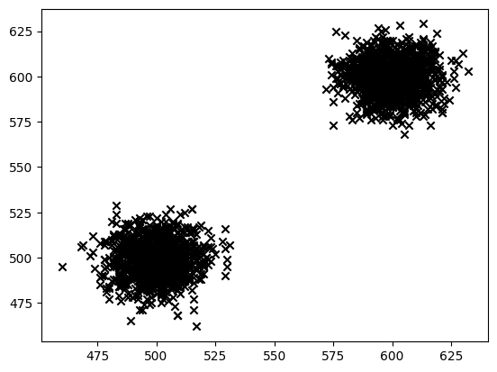

```python
import matplotlib.pyplot as plt

# download the file into a dataframes and convert it to a numpy array.
data_test = pd.read_csv("https://www.dropbox.com/s/gax1l68jsarxqt9/data_test.txt?dl=1", header=None).to_numpy()

#plot the points into a scatter plot
plt.scatter(data_test[:, 0], data_test[:,1], color ='k', marker='x')
```

### Step 2

Write a function named **init** that takes two arguments: $points$ and $K$.  
The function **init** should return a numpy ndarray with $K$ elements sampled randomly and without replacement from $points$. Meaning, the same point should not be picked up twice.

**Show that your function performs as desired by calling it with** $K = 2$ **and on the data_test as the** $points$.

```python
def init(points, K):
    """
    Initialize cluster centroids by randomly selecting K unique points from the dataset.

    Parameters
    ----------
    points: numpy.ndarray
        The dataset containing points, where each row represents a point.

    k: int
        The number of clusters.

    Returns
    ----------
    numpy.ndarray: An array containing K randomly selected points as initial centroids.

    """
    # np.random.choice() generates random samples
    # points.shape[0] is used to determine the number of rows in the points array, so it specifies the range of integers from which we need to sample
    # k is the number of clusters we want to use in our k-means algorithm
    # the replace=False will ensure that the random sampling is done without replacement
    return points[np.random.choice(points.shape[0], K, replace=False)]

init(data_test, 2)
```

```
array([[589, 601],
       [591, 605]])
```

### Step 3

Write a function named **distance** that takes two arguments: $p1$ and $p2$.  
The function **distance** should return a scalar that corresponds to the euclidian distance between points $p1$ and $p2$, that should have a ndarray format.  
For the assignment you can assume that $p1$ and $p2$ are two-dimensional ndarrays points. But in general, you should assume that p1 and p2 are two ndarrays of the same size.

Recall that the euclidian distance (d) between two points ($p_1$ and $p_2$) in a 2-dimensional space is given by:  
\begin{equation} d(p_1, p_2) = \sqrt{(x_1-x_2)^2 + (y_1-y_2)^2} \end{equation}  
where $p_1 = \{x_1,y_1\}$ and $p_2 = \{x_2,y_2\}$.

**Test your function works by computing the distance between p1=(1,3) and p2=(7,2), which is $\approx$ 6.08.**

**Consider using the existing Numpy or Scipy packages for this task**

Can you write a function that computes the euclidian distance between two points of arbitrary dimension?  
In general, for arbitrary dimensionality the square of the distance can be computed as:  
\begin{equation} d^2(p_1, p_2) = \sum_{i=0}^{D-1} (x_i-y_i)^2 \end{equation}  
where $p_1 = \{x_1,x_2,...,x_{D-1}, x_D\}$ and $p_2 = \{y_1,y_2,...,y_{D-1},y_D\}$.

**Show your function works by computing the distance between (1,3,-9,12) and (7,2,0,5)**

```python
def distance(p1, p2):
    """
    Calculate the Euclidean distance between two points of arbitrary dimension.

    Parameters
    ----------
        p1: numpy.ndarray
            The first point as a n-dimensional ndarray.

        p2: numpy.ndarray
            The second point as a n-dimensional ndarray.

    Returns
    ---------
        float: The Euclidean distance between the two points.
    """
    # calculates the Euclidean distance between two points
    return np.linalg.norm(p1 - p2)
```

```python
# Test variables do not change
p1 = np.array([1,3])
p2 = np.array([7,2])
```

```python
distance(p1,p2)
```

```
6.082762530298219
```

```python
p3 = np.array([1,3,-9,12])
p4 = np.array([7,2,0,5])

distance(p3,p4)
```

```
12.922847983320086
```

### Step 4

Write a function named **centroid** that takes one argument: $points$.

The argument $points$ should be a ndarray with the coordinates of a set of observations.

The function **centroid** should return an ndarray with $d$ values (being $d$ the number of dimensions)</span>, the $n^{th}$ index of the returned output ndarray should thus correspond to the averaged of the values in the $n^{th}$ column of the points ndarray. In other words, correspond to the average position along a specific dimension of observations in $points$.</span>

**Test your function and check that it works by using the ndarray TEST**

```python
def centroid(points):
    """
    Calculate the centroid of a set of observations.

    Parameters
    ----------
    points: numpy.ndarray
        An ndarray with the coordinates of observations.
        Each row represents a point, and each column represents a dimension.

    Returns
    ---------
        numpy.ndarray: An array containing the averaged values along each dimension.
    """
    # calculates the mean (average) along a specific axis, in this case, axis=0
    # axis=0 goes through each row so it averages each column across all data points
    return np.mean(points, axis=0)
```

```python
#Test variables do not change the values
TEST = np.array([[1,2,3,4,5],[0,0,1,1,1],[0,1,2,4,5]])
print(TEST)
```

```
[[1 2 3 4 5]
 [0 0 1 1 1]
 [0 1 2 4 5]]
```

```python
centroid(TEST)
```

```
array([0.33333333, 1.        , 2.        , 3.        , 3.66666667])
```

### Step 5

Write a function **cupdate** that takes two input arguments: *points* and *clusters*

The argument *points* is a ndarray containing the coordinates of a set of points (1 point per row).

The argument *clusters* is a 1-dimensional ndarray that indicates the cluster to which each point is associated.

Note that values in *clusters* are integers and can only take values between 0 and K-1, where K is the total number of clusters.

The function **cupdate** should return an ndarray with the average coordinates of the points associated to each cluster, that is the centroid of each cluster. The returned array should have the same number of columns as points (dimensions) and length K (rows).

**Test your function and report the centroids generated by passing p and c as inputs with k = 3. Save these centroids as a variable: cen**

```python
def cupdate(points, clusters):
    """
    Update centroids based on the cluster assignments.

    Parameters
    ----------
        points: numpy.ndarray
            An ndarray containing the coordinates of points.
            Each row represents a point, and each column represents a dimension.

        clusters: numpy.ndarray
            A 1-dimensional ndarray indicating the cluster to which each point is associated.

    Returns:
        numpy.ndarray: An array containing the average coordinates of the points associated with each cluster (centroids).
            The array has the same number of columns as points (dimensions) and length K (rows).
    """
    # will give us the number of clusters in "clusters", since np.max() calculates tha maximum value corresponding to the highest cluster index
    # since our indexes start from 0, we add 1 and we have our final numbers of clusters
    K = int(np.max(clusters) + 1)
    # created a matrix with K rows, and points.shape[1] columns full of zeros to use when we update the centroids for each cluster based on the mean of the data points in each cluster
    centroids = np.zeros((K, points.shape[1]))

    # runs through all clusters
    for k in range(K):
        # takes the points from the respective cluster
        cluster_points = points[clusters == k]
        # calculates the average/ mean with the centroid function and updates the centroids
        centroids[k] = centroid(cluster_points)
    return centroids
```

```python
# Test variables, do not change the values
p = np.array([[0.8922063, 0.26672425],[0.34475611, 0.35976697],[0.33253499, 0.18923898],[0.66872466, 0.46248986],[0.72823733, 0.10537784],[0.40903598, 0.70639412],[0.79926596, 0.90095583],[0.67886544, 0.84573289],[0.3641813, 0.64296743],[0.07461196, 0.74290527]])
c = np.array([2, 0, 0, 1, 1, 0, 0, 1, 0, 1])

cen = cupdate(p, c)
```

```python
cen
```

```
array([[0.44995487, 0.55986467],
       [0.53760985, 0.53912646],
       [0.8922063 , 0.26672425]])
```

### Step 6

Write a function **pupdate** that takes two input arguments: $points$ and $centroids$.

The function **pupdate** should return a one-dimensional ndarray that indicates the index of the centroid that is closer to each point. To determine the distance between a centroid and a point you can use your distance function you created earlier.

You will need to assess the distance between each point to each centroid. Different approaches can be taken to do this. For instance, you can start by computing a *$d$ by $k$* distance matrix matrix between each of the $d$ points and the $k$ centroids.

**Test your function by calling it and passing the array p (as defined above) with the output of cupdate, cen, as arguments. You should get an output that looks like c defined above (but is not exactly the same, can you see why). Print this result and save it in a variable called new_clusters**

```python
def pupdate(points, centroids):
    """
    Assign each point to the closest centroid based on Euclidean distance.

    Parameters
    ----------
        points: ndarray
            Array of data points, where each row represents a point.

        centroids: ndarray
            Array of centroid coordinates, where each row represents a centroid.

    Returns
    ---------
        ndarray: Array indicating the index of the closest centroid for each point.

    """
    # array to store the indices of the closest centroids
    # dtype=int to return an array with integers
    closest_centroids = np.zeros(len(points), dtype=int)

    # run through each point
    for i, point in enumerate(points):
        # calculate the distances from the point to all the centroids
        distances = [distance(point, centroid) for centroid in centroids]
        # find the index of the closest centroid
        closest_centroid_index = np.argmin(distances)
        # assign the index of the closest centroid to the corresponding point
        closest_centroids[i] = closest_centroid_index

    return closest_centroids

new_clusters = pupdate(p, cupdate(p, c))
```

```python
print(new_clusters)
```

```
[2 0 0 1 2 0 1 1 0 0]
```

### Step 7

Write a function **error** that takes two input arguments: oldcentroids and newcentroids.

The argument oldcentroids corresponds to a ndarray with centroid positions from the previous iteration, and newcentroids to a ndarray with the newly computed centroid positions from the current iteration.

The function **error** should return the average euclidian distance (the square error) between the old and new positions of each centroid. This will give us a quantity that tell us whether our algorithm is still converging to the solution or got to good approximation.</span> We will use the function error to obtain an estimate of whether the algorithm is still converging to the solution (that is the centroids are, in average, moving a lot) or if we entered a scenario of small steps (that is the centroids are, in average, not moving that much).

We will use this information combined with a **tolerance threshold** in regards to the average change in the centroids positions to decide if it is a good time to stop the algorithm. You should make this decision.

**Test your function and then report the distance between the centroids computed in Step 5, cen, and the centroids that you can compute using the function cupdate with the arguments points and new_clusters.**

```python
def error(oldcentroids, newcentroids):
    """
    Calculate the average Euclidean distance (squared error) between old and new centroid positions.

    Parameters
    ----------
        oldcentroids: ndarray
            Array of centroid positions from the previous iteration.

        newcentroids: ndarray
            Array of newly computed centroid positions from the current iteration.

    Returns
    ---------
        float: Average squared error between old and new centroid positions.
    """
    # empty list to store the squared errors for each cluster
    sq_error = []
    # loop iterates over each row which corresponds to a cluster
    for row in range(len(oldcentroids)):
        # calculates the distance between the old centroid and the new centroid for the current cluster
        sq_error.append(distance(oldcentroids[row], newcentroids[row]))
    # calculates the mean of the squared errors list
    return np.mean(sq_error)
```

```python
error(cen, cupdate(p, new_clusters))
```

```
0.17635560837965428
```

### Step 8

Write a wrapper function called **kmeans** that takes the following arguments:

- $points$, which is a ndarray of points;
- $K$, the number of clusters, set the default value to two;
- $niter$, the number of iterations;
- $tol$, the error tolerance threshold below which your algorithm should stop

The function should return:

- A one dimensional ndarray with the cluster of associated to each point,
- A ndarray with the location of the K centroids.

Use the functions you prepared previously to assemble the function **kmeans**.  
Use the tolerance as a treshold to stop the algorithm, for instance by evaluating if the average variation in the distance between the new and previous coordinates of the centroids is below the tolerance level. If yes, then you can stop the algorithm and return the outputs.

**You will need to make some decisions about the best approach to select the correct range of values to pass to init(), particularly pay attention to the values given for K, as K-Means is extremely sensitive to the number of centroids being chosen. Justify your decision.**

**Note: A common issue with the K-means algorithm is that in some limiting conditions it might lead to empty clusters. In that case it is expected that your algorithm returnr an error. Although that shoudl not happen with the examples provided, you might want to consider implementing some heuristics to overcome those errors.However, this is an optional task, and for this homework if you bump into such errors we recommend you try to rerun your code.**

```python
# We explain our aproach decision in Step 10
```

```python
def kmeans(points,niter,tol,K=2):
    """
    Perform K-means clustering on a set of points.

    Parameters
    ----------
        points: ndarray
            Array of data points, where each row represents a point.

        niter: int
            Maximum number of iterations.

        tol: int or float
            Tolerance threshold for convergence.

        K: int
            Number of clusters. Default is 2.
    Returns
    ---------
        list: A list containing two elements:
            - A one-dimensional ndarray with the cluster associated with each point.
            - A ndarray with the coordinates of the K centroids.
    """
    # used to store the clustering information for each iteration
    thelist = []

    # initialized with a large value (9e99) to make sure that the k-means algorithm runs for at least one iteration
    error_1 = 9e99

    # generates the initial centroids
    centroids = init(points, K)

    # loop runs for a maximum of niter iterations
    for _ in range(niter):
        # assigns each point to the nearest centroid
        new_clusters = pupdate(points,centroids)
        # calculates new centroids based on the updated clusters
        new_centroids = cupdate(points, new_clusters)
        # gives us the average euclidian distance between the old and new positions of each centroid.
        error_1 = error(centroids,new_centroids)
        # update the current centroids with the newly computed centroids
        centroids = new_centroids
        # if error_1 is less than tol, the program terminates and the current clusters and centroids are returned as a list
        if error_1 < tol:
            return new_clusters,new_centroids

        thelist.append([new_clusters,new_centroids, error_1])

        # returns the final clustering results based on the lowest error encountered during the iterations
        lowest_error = sorted(thelist,key = lambda x : x[-1])[0]
    return lowest_error[:2]
```

```python
kmeans(data_test,10,0.00001)
```

```
(array([0, 0, 0, ..., 1, 1, 1]),
 array([[499.65527344, 498.94433594],
        [599.49853372, 599.63538612]]))
```

It is useful to visually inspect the results in order to assess the performance of the clustering algorthim.  
Below is an example of how you can visualize your results for a sample dataset.  
Can you adapt the code to show your results applied to data_test with K = 2, niter = 500, tol = 0.00001.

**In this step feel free to use any other visualization library such as Seaborn. **

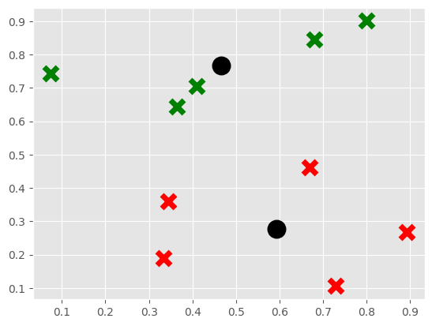

```python
#boilerplate
import numpy as np
import matplotlib.pyplot as plt
from matplotlib import style

# let us define the style of the plot here
style.use('ggplot')
colors = ["g","r","c","b"]

# sample data for this example
p = np.array([[0.8922063, 0.26672425],[0.34475611, 0.35976697],[0.33253499, 0.18923898],[0.66872466, 0.46248986],[0.72823733, 0.10537784],[0.40903598, 0.70639412],[0.79926596, 0.90095583],[0.67886544, 0.84573289],[0.3641813, 0.64296743],[0.07461196, 0.74290527]])
centroids = [np.array([0.46519213, 0.76779111]),np.array([0.59329188, 0.27671958])]
clusters = np.array([1, 1, 1, 1, 1, 0, 0, 0, 0, 0])

# plot each point in the centroids array
for centroid_ in centroids:
    plt.scatter(centroid_[0],centroid_[1], marker="o", color="k", s=150, linewidths=5)

# plot each point in the points array, colored according to the cluster they belong
for i in range(len(clusters)):
    plt.scatter(p[i,0],p[i,1], marker="x", color=colors[clusters[i]], s=150, linewidths=5)

# plot all elements
plt.show()
```

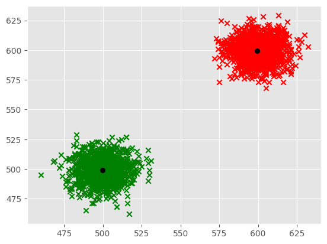

```python
from matplotlib import style

# let us define the style of the plot here
style.use('ggplot')
colors = ["g","r","c","b"]

clusters, centroids = kmeans(data_test, 500, 0.00001, 2)

# plot each point in the points array, colored according to the cluster they belong
for i in range(len(clusters)):
    plt.scatter(data_test[i,0],data_test[i,1], marker="x", color=colors[clusters[i]])

# plot each point in the centroids array
for centroid_ in centroids:
    plt.scatter(centroid_[0],centroid_[1], marker="o", color="k")

# plot all elements
plt.show()
```

### Step 9

Write a function **inertia** that takes three input arguments: $points$, $clusters$, and $centroids$.  
Where $points$ is a 2-dimensional ndarray with the coordinates of each point in your dataset, clusters is a vector that indicates the cluster of each point (takes values between $0$ and $K-1$), and $centroids$ is a 2-dimensional ndarray with length $k$ of the coordinates of the centroids.

The function should return a tuple in which the first value is the number of clusters and the second is the computed **average squared Euclidean distance** of the points to the centroid of the cluster they are assigned. The Squared of the Euclidean distance is a common measure of error that satisfies several important properties, namely it is strictly convex and smooth. It is often used in the method of Least Squares to fit linear functions to data, in which we try to find the parameters of a linear model that minimize the average of the square distances between the observed values and the values predicted by the fitted model. Here we are borrowing these concepts to measure the dispersion of points in a cluster, in other words, the error between the position of the centroid and the locations of the points associated with it.

**Test your function and report the results of using point=p, clusters=c, and centroids=cen. These are the variables that you have used in the previous steps.**

**Note: distance always refers to the euclidean distance.**

```python
def inertia(points, clusters, centroids):
    """
    Calculate the inertia of the clustering.
    Inertia is defined as the average squared distance between each point and its assigned centroid.

    Parameters
    ----------
        points: ndarray
            Array of data points, where each row represents a point.

        clusters: ndarray
            Array indicating the cluster assignment for each point.

        centroids: ndarray
            Array of centroid coordinates, where each row represents a centroid.

    Returns
    ----------
        tuple: A tuple containing the number of clusters and the inertia value.

    """
    n_clusters = len(centroids)

    # calculates the distance between each data point and its assigned centroid
    dist_list = [distance(point, centroids[cluster]) for point, cluster in zip(points, clusters)]

    # squares each distance value
    squared_dist_list = [x**2 for x in dist_list]

    # tuple containing the number of clusters (n_clusters) and the mean of the squared distances
    return tuple([n_clusters, np.mean(squared_dist_list)])
```

```python
inertia(p, c, cen)
```

```
(3, 0.10954209828084607)
```

### Step 10

Load the data from file https://www.dropbox.com/s/wco3lxgn1f4a5k2/data_custering.csv?dl=1 into numpy array.  
The data consists of the coordinates of $N$ points in a 2-dimensional space.  
Use the functions **kmeans** and **inertia** to identify the most suitable number of clusters.  
**You must consider doing some visual inspection and reporting**. For instance:

- Inspect visually the dataset before performing the clustering.
- Report the inertia values as a line plot.
- Show the result of your clustering.

*Tip: use the output of inertia to perform the elbow method https://en.wikipedia.org/wiki/Elbow_method_(clustering).*

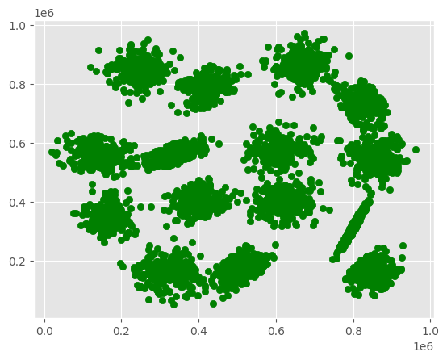

```python
data = np.array(pd.read_csv("https://www.dropbox.com/s/wco3lxgn1f4a5k2/data_custering.csv?dl=1"))

plt.scatter(data[:,0],data[:,1], color="green")
plt.show()
```

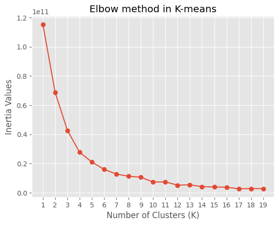

```python
# store the inertia results for different numbers of clusters
# used to create a DataFrame for easier visualization and debug
df_inertia = []

# we used this values since was also used in step 8
niter = 500
tol = 0.00001

# loop over a range of values for the number of clusters(K)
for K in range(1,20):
    # list containing the cluster assignments and centroids where we use kmeans clustering on the data_clustering data with K clusters
    clusters, centroids = kmeans(data,niter,tol,K)

    # use of the inertia function to get the tuple containing the number of clusters (n_clusters) and the mean of the squared distances for K clusters
    n_cluster, inertia_value = inertia(data, clusters, centroids)
    # append rows with (number os clusters, inertia values) to our df
    new_row = [n_cluster, inertia_value]
    df_inertia.append(new_row)
df_inertia = pd.DataFrame(df_inertia, columns=["number_of_clusters", "inertia"])

# plotting our results
plt.plot(df_inertia["number_of_clusters"], df_inertia["inertia"], marker="o")
plt.title("Elbow method in K-means")
plt.xlabel("Number of Clusters (K)")
plt.ylabel("Inertia Values")
plt.xticks(np.arange(1,20,1))
plt.show()
```

## Finding the best number of clusters (K)

#### The elbow method is based on the idea that as you increase the number of clusters, the variation within each cluster decreases, but at some point, the improvement becomes insignificant. This point is called the elbow and indicates the ideal number of clusters for your data.

#### In this case choosing the best k for the elbow method is a challenge, as the elbow point is not distinct or apparent. To make a more detailed selection of the best number of clusters we have various methods such as a scree plot which can visualise the percentage of variance explained by each cluster, the Davies-Bouldin index which can quantify the variation within each cluster, Silhouette Analysis and scale Inertia for example.

#### We chose to scale our inertia values, because we wanted to sustain our visualization aproach.

##### More info about the method here : https://towardsdatascience.com/an-approach-for-choosing-number-of-clusters-for-k-means-c28e614ecb2c

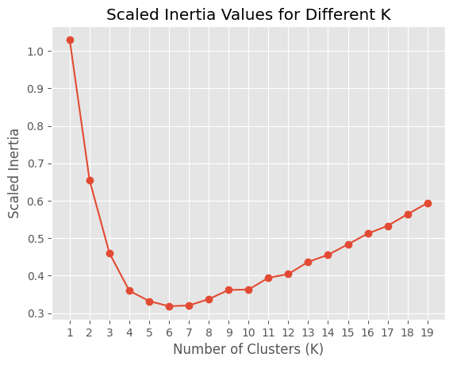

```python
# scale the values of inertia, using a penalization of 0.03 for each value of k
arr_inertia = np.array(df_inertia["inertia"])
scaled_inertia = arr_inertia*1/arr_inertia[0]+0.03*np.arange(1,20)

# Create plot
plt.plot(df_inertia["number_of_clusters"], scaled_inertia, marker='o')
plt.title("Scaled Inertia Values for Different K")
plt.xlabel("Number of Clusters (K)")
plt.xticks(np.arange(1,20,1))
plt.ylabel("Scaled Inertia")
plt.show()
```

#### We decided to choose 6 clusters, because it´s the value where the line appears to form the minimum of our parable.

#### Note: Even with this method, we have disadvantages, such as the subjectivity in choosing a penalisation value. Our final number of clusters may be different due to the fact that the initial centroids are random and the inertia values are slightly different each time.

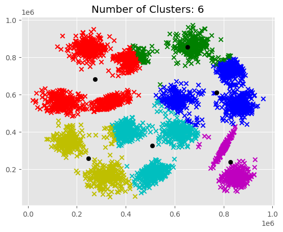

```python
# let us define the style of the plot here
style.use('ggplot')
colors = ["g","r","c","b","m","y"]


clusters, centroids = kmeans(data, 500, 0.00001, 6)

# plot each point in the points array, colored according to the cluster they belong
for i in range(len(clusters)):
    plt.scatter(data[i,0],data[i,1], marker="x", color=colors[clusters[i]])

# plot each point in the centroids array
for centroid_ in centroids:
    plt.scatter(centroid_[0],centroid_[1], marker="o", color="k")


# plot all elements
plt.title("Number of Clusters: 6")
plt.show()
```